# R Notebook for Prosper Loan Data

# A. PREPARING RSTUDIO AND THE DATA SET

### A1. Installing the packages as instructed in the rubric.

```r
library("ggplot2")
library("knitr")
library("dplyr")
library(gridExtra)
```

### A2. Opening the Data Set

```r
getwd()
```

```
[1] "C:/Users/Nancy Olewnik/Documents"
```

```r
pf <- read.csv('prosperLoanData.csv')
names(pf)
```

```
 [1] "ListingKey"
 [2] "ListingNumber"
 [3] "ListingCreationDate"
 [4] "CreditGrade"
 [5] "Term"
 [6] "LoanStatus"
 [7] "ClosedDate"
 [8] "BorrowerAPR"
 [9] "BorrowerRate"
[10] "LenderYield"
[11] "EstimatedEffectiveYield"
[12] "EstimatedLoss"
[13] "EstimatedReturn"
[14] "ProsperRating..numeric."
[15] "ProsperRating..Alpha."
```

[output cut: 66 more lines]

### A3. Running the data & summary files

```r
data(pf)
```

```
data set pf not found
```

```r
summary(pf)
```

```
                   ListingKey     ListingNumber
 17A93590655669644DB4C06:     6   Min.   :      4
 349D3587495831350F0F648:     4   1st Qu.: 400919
 47C1359638497431975670B:     4   Median : 600554
 8474358854651984137201C:     4   Mean   : 627886
 DE8535960513435199406CE:     4   3rd Qu.: 892634
 04C13599434217079754AEE:     3   Max.   :1255725
 (Other)                :113912
                    ListingCreationDate  CreditGrade
 2013-10-02 17:20:16.550000000:     6          :84984
 2013-08-28 20:31:41.107000000:     4   C      : 5649
 2013-09-08 09:27:44.853000000:     4   D      : 5153
 2013-12-06 05:43:13.830000000:     4   B      : 4389
 2013-12-06 11:44:58.283000000:     4   AA     : 3509
 2013-08-21 07:25:22.360000000:     3   HR     : 3508
 (Other)                      :113912   (Other): 6745
      Term                       LoanStatus
 Min.   :12.00   Current              :56576
 1st Qu.:36.00   Completed            :38074
 Median :36.00   Chargedoff           :11992
 Mean   :40.83   Defaulted            : 5018
 3rd Qu.:36.00   Past Due (1-15 days) :  806
 Max.   :60.00   Past Due (31-60 days):  363
                 (Other)              : 1108
               ClosedDate     BorrowerAPR       BorrowerRate
                    :58848   Min.   :0.00653   Min.   :0.0000
 2014-03-04 00:00:00:  105   1st Qu.:0.15629   1st Qu.:0.1340
 2014-02-19 00:00:00:  100   Median :0.20976   Median :0.1840
 2014-02-11 00:00:00:   92   Mean   :0.21883   Mean   :0.1928
 2012-10-30 00:00:00:   81   3rd Qu.:0.28381   3rd Qu.:0.2500
 2013-02-26 00:00:00:   78   Max.   :0.51229   Max.   :0.4975
 (Other)            :54633   NA's   :25
  LenderYield      EstimatedEffectiveYield EstimatedLoss
 Min.   :-0.0100   Min.   :-0.183          Min.   :0.005
 1st Qu.: 0.1242   1st Qu.: 0.116          1st Qu.:0.042
 Median : 0.1730   Median : 0.162          Median :0.072
 Mean   : 0.1827   Mean   : 0.169          Mean   :0.080
 3rd Qu.: 0.2400   3rd Qu.: 0.224          3rd Qu.:0.112
 Max.   : 0.4925   Max.   : 0.320          Max.   :0.366
                   NA's   :29084           NA's   :29084
```

[output cut: 232 more lines]

```
 Recommendations    InvestmentFromFriendsCount
 Min.   : 0.00000   Min.   : 0.00000
 1st Qu.: 0.00000   1st Qu.: 0.00000
 Median : 0.00000   Median : 0.00000
 Mean   : 0.04803   Mean   : 0.02346
 3rd Qu.: 0.00000   3rd Qu.: 0.00000
 Max.   :39.00000   Max.   :33.00000

 InvestmentFromFriendsAmount   Investors
 Min.   :    0.00            Min.   :   1.00
 1st Qu.:    0.00            1st Qu.:   2.00
 Median :    0.00            Median :  44.00
 Mean   :   16.55            Mean   :  80.48
 3rd Qu.:    0.00            3rd Qu.: 115.00
 Max.   :25000.00            Max.   :1189.00
```

### A4. Does my data set over 1,000 observations? Are there at least 8 different variables?

```r
dim(pf)
```

```
[1] 113937     81
```

113,937 observations with 81 variables

### A5. Does my data set contain at leasT one categorical variable?

```r
lapply(pf,class)
```

```
$ListingKey
[1] "factor"

$ListingNumber
[1] "integer"

$ListingCreationDate
[1] "factor"

$CreditGrade
[1] "factor"

$Term
[1] "integer"

$LoanStatus
[1] "factor"

$ClosedDate
[1] "factor"

$BorrowerAPR
[1] "numeric"

$BorrowerRate
[1] "numeric"

$LenderYield
[1] "numeric"

$EstimatedEffectiveYield
[1] "numeric"

$EstimatedLoss
[1] "numeric"

$EstimatedReturn
[1] "numeric"

$ProsperRating..numeric.
```

[output cut: 187 more lines]

```

$PercentFunded
[1] "numeric"

$Recommendations
[1] "integer"

$InvestmentFromFriendsCount
[1] "integer"

$InvestmentFromFriendsAmount
[1] "numeric"

$Investors
[1] "integer"
```

### A6. List out the description of variables and types

```r
str(pf)
```

```
'data.frame':   113937 obs. of  81 variables:
 $ ListingKey                         : Factor w/ 113066 levels "00003546482094282EF90E5",..: 7180 7193 6647 6669 6686 6689 6699 6706 6687 6687 ...
 $ ListingNumber                      : int  193129 1209647 81716 658116 909464 1074836 750899 768193 1023355 1023355 ...
 $ ListingCreationDate                : Factor w/ 113064 levels "2005-11-09 20:44:28.847000000",..: 14184 111894 6429 64760 85967 100310 72556 74019 97834 97834 ...
 $ CreditGrade                        : Factor w/ 9 levels "","A","AA","B",..: 5 1 8 1 1 1 1 1 1 1 ...
 $ Term                               : int  36 36 36 36 36 60 36 36 36 36 ...
 $ LoanStatus                         : Factor w/ 12 levels "Cancelled","Chargedoff",..: 3 4 3 4 4 4 4 4 4 4 ...
 $ ClosedDate                         : Factor w/ 2803 levels "","2005-11-25 00:00:00",..: 1138 1 1263 1 1 1 1 1 1 1 ...
 $ BorrowerAPR                        : num  0.165 0.12 0.283 0.125 0.246 ...
 $ BorrowerRate                       : num  0.158 0.092 0.275 0.0974 0.2085 ...
 $ LenderYield                        : num  0.138 0.082 0.24 0.0874 0.1985 ...
 $ EstimatedEffectiveYield            : num  NA 0.0796 NA 0.0849 0.1832 ...
 $ EstimatedLoss                      : num  NA 0.0249 NA 0.0249 0.0925 ...
 $ EstimatedReturn                    : num  NA 0.0547 NA 0.06 0.0907 ...
 $ ProsperRating..numeric.            : int  NA 6 NA 6 3 5 2 4 7 7 ...
```

[output cut: 67 more lines]

# B. UNIVARIATE PLOT SECTIION

### B0. Factorizing rating for the key variable we’d investigate throughout the dataset

```r
pf$ProsperRating.alpha = factor(pf$ProsperRating..Alpha.,
                                 levels = c("AA","A","B","C","D","E","HR","NA"))
pf$ProsperRating <-factor(pf$ProsperRating..Alpha,
                        levels = c('AA', 'A', 'B', 'C', 'D', 'E', 'HR', 'NA'))
pf$ProsperScore = factor(pf$ProsperScore)
```

### B1. HISTOGRAM OF PROSPER RATING BY NUMBERS OF LOANS

```
Ignoring unknown parameters: binwidth, bins, pad
```

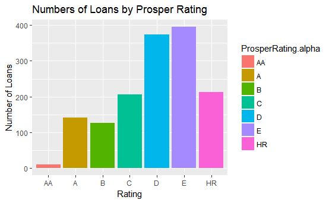

```r
ggplot(data = na.omit(pf), aes(ProsperRating.alpha)) +
  geom_histogram(aes(fill = ProsperRating.alpha),stat="count") +
  ggtitle('Numbers of Loans by Prosper Rating') +
  xlab('Rating') +
  ylab('Number of Loans')
```

```r
summary(pf$ProsperRating.alpha)
```

```
   AA     A     B     C     D     E    HR    NA  NA's
 5372 14551 15581 18345 14274  9795  6935     0 29084
```

### B1 - Part 2. PROSPER RATING DISTRIBUTION

```r
table(pf$ProsperRating..numeric., useNA = 'ifany')
```

```
    1     2     3     4     5     6     7  <NA>
 6935  9795 14274 18345 15581 14551  5372 29084
```

```r
summary(pf$ProsperRating..numeric., useNA = 'ifany')
```

```
   Min. 1st Qu.  Median    Mean 3rd Qu.    Max.    NA's
  1.000   3.000   4.000   4.072   5.000   7.000   29084
```

The NA count of Prosper Rating and Prosper Score is similar (29,084). I’m curious how the Prosper Rating and Prosper Score varies.

### B2. PROSPER SCORE DISTRIBUTION

```
Ignoring unknown parameters: binwidth, bins, padIgnoring unknown aesthetics: vjust, hjust
```

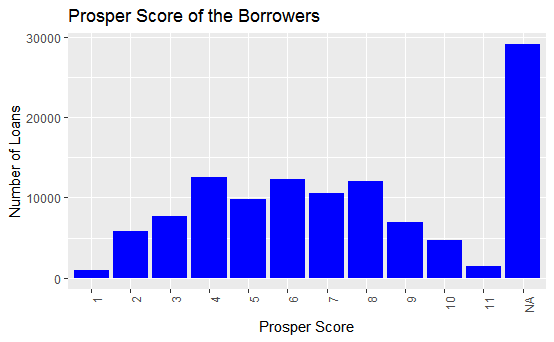

```r
ggplot(pf, aes(x=ProsperScore)) +
                geom_histogram(aes(y=..count.., vjust=-0.9,   hjust=0.5), binwidth=500, size = 3, fill="blue", stat="count") +
  ggtitle('Prosper Score of the Borrowers') +
  xlab('Prosper Score') +
  ylab('Number of Loans') +
  theme(axis.text.x = element_text(angle = 90, hjust = 1))
```

```r
summary(pf$ListingCategory)
```

```
   Min. 1st Qu.  Median    Mean 3rd Qu.    Max.
  0.000   1.000   1.000   2.774   3.000  20.000
```

Again, the majority of the scores are “NA” and in the 4-8. category range. Why are there so many ProsperScores that are NA?

### B3. BORROWER INCOME RANGE

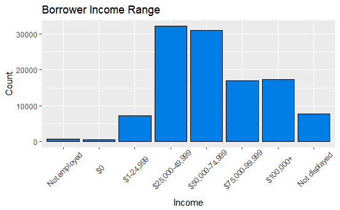

```r
pf$IncomeRange = factor(pf$IncomeRange, levels=c("Not employed", "$0", "$1-24,999", "$25,000-49,999", "$50,000-74,999", "$75,000-99,999", "$100,000+", "Not displayed"))
ggplot(data = pf, aes(IncomeRange)) +
  geom_bar(color="black", fill = '#007EE5') +
  ggtitle('Borrower Income Range') +
  xlab('Income') +
  theme(axis.text.x = element_text(angle = 45, vjust = 0.6)) +
  ylab('Count')
```

The majority of borrowers are in the $25,000 - $75,000 range. I suspect this lower-middle class range needs loans for debt consolidations.

### B4. DEBT TO INCOME RATIO

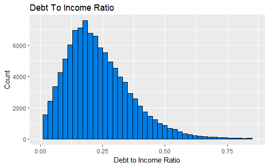

```r
ggplot(data = pf, aes(x = DebtToIncomeRatio)) +
        geom_histogram(color = "black", fill = '#007EE5', binwidth = 0.02) +
        xlim(0, quantile(pf$DebtToIncomeRatio, prob = 0.99, na.rm=TRUE)) +
        ggtitle("Debt To Income Ratio") +
        xlab("Debt to Income Ratio") +
        ylab("Count")
```

The data is long-tailed right-skewed. It’s expected the majority of people in U.S have a credit history and the ratio should be low enough for a secured repayment.

### B5. BORROWER’S PURPOSE OF LOAN

```
Ignoring unknown parameters: binwidth, bins, padIgnoring unknown aesthetics: vjust, hjust
```

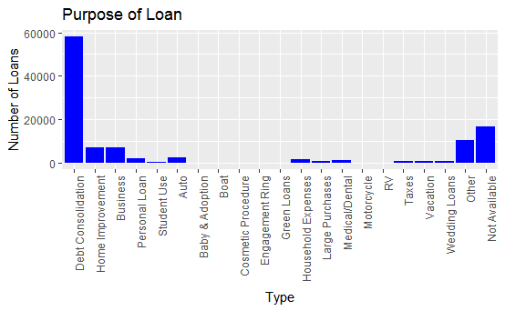

```r
x <- c('Debt Consolidation',
                                'Home Improvement','Business',
                                 'Personal Loan',
                                 'Student Use',
                                 'Auto',
                                 'Baby & Adoption',
                                 'Boat',
                                 'Cosmetic Procedure',
                                 'Engagement Ring',
                                 'Green Loans',
                                 'Household Expenses',
                                 'Large Purchases',
                                 'Medical/Dental',
                                 'Motorcycle', 'RV',
                                 'Taxes', 'Vacation',
                                 'Wedding Loans',
                                 'Other',
                                 'Not Available')
pf$ListingCategory <- factor(pf$ListingCategory..numeric., levels = c(1:6,8:20,7,0), labels = x)
ggplot(pf, aes(x=ListingCategory)) +
                geom_histogram(aes(y=..count.., vjust=-0.9,   hjust=0.5), binwidth=500, size = 3, fill="blue",stat="count") +
  ggtitle('Purpose of Loan') +
  xlab('Type') +
  ylab('Number of Loans') +
  theme(axis.text.x = element_text(angle = 90, hjust = 1))
```

```r
summary(pf$ListingCategory)
```

```
Debt Consolidation   Home Improvement           Business
             58308               7433               7189
     Personal Loan        Student Use               Auto
              2395                756               2572
   Baby & Adoption               Boat Cosmetic Procedure
               199                 85                 91
   Engagement Ring        Green Loans Household Expenses
               217                 59               1996
   Large Purchases     Medical/Dental         Motorcycle
               876               1522                304
                RV              Taxes           Vacation
                52                885                768
     Wedding Loans              Other      Not Available
               771              10494              16965
```

### B7. LOAN SPLIT BY AMOUNT

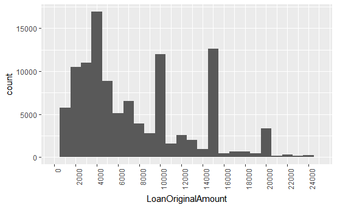

```r
ggplot(pf, aes(LoanOriginalAmount)) +
                geom_histogram(binwidth = 1000) +
                scale_x_continuous(
                limits = c(0,quantile(pf$LoanOriginalAmount, 0.99,
                                                        na.rm = TRUE)),
                breaks = seq(0, quantile(pf$LoanOriginalAmount, 0.99,
                                                  na.rm = TRUE), 2000)) +
                theme(axis.text.x = element_text(angle = 90, hjust = 1))
```

```r
summary(pf$LoanOriginalAmount)
```

```
   Min. 1st Qu.  Median    Mean 3rd Qu.    Max.
   1000    4000    6500    8337   12000   35000
```

### B8. EMPLOYMENT STATUS

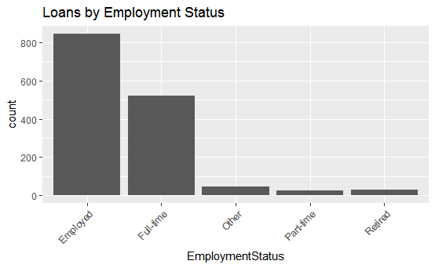

```r
ggplot(aes(x = EmploymentStatus), data = na.omit(pf)) +
                    geom_bar() +
                    theme(axis.text.x = element_text(angle = 45, hjust = 1)) +
                    ggtitle("Loans by Employment Status")
```

```r
summary(pf$EmploymentStatus)
```

```
                   Employed     Full-time Not available
         2255         67322         26355          5347
 Not employed         Other     Part-time       Retired
          835          3806          1088           795
Self-employed
         6134
```

This chart shows that the majority is employed; however, this data could be skewed. Does the “employed” data include part-time or full-time?

### B9. STATED MONTHLY INCOME

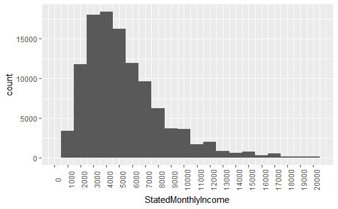

```r
ggplot(aes(x = StatedMonthlyIncome), data = pf) +
                  geom_histogram(binwidth = 1000) +
                  scale_x_continuous(
                  limits = c(0, quantile(pf$StatedMonthlyIncome, 0.99,
                                                              na.rm = TRUE)),
                  breaks = seq(0, quantile(pf$StatedMonthlyIncome, 0.99,
                                                      na.rm = TRUE), 1000)) +
                  theme(axis.text.x = element_text(angle = 90))
```

```r
summary(pf$StatedMonthlyIncome)
```

```
   Min. 1st Qu.  Median    Mean 3rd Qu.    Max.
      0    3200    4667    5608    6825 1750000
```

This chart tells us the most popular stated monthly income is $4,000 - $5,000.

### B10. BORROWER’S RATE

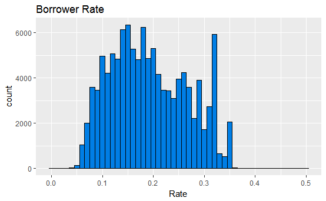

```r
ggplot(data = pf, aes(x = BorrowerRate)) +
        geom_histogram(color = "black", fill = '#007EE5', binwidth = 0.01) +
        xlab("Rate") +
        ggtitle("Borrower Rate")
```

```r
summary(pf$BorrowerRate)
```

```
   Min. 1st Qu.  Median    Mean 3rd Qu.    Max.
 0.0000  0.1340  0.1840  0.1928  0.2500  0.4975
```

The most frequent rates are approximately 15%, 17% and 32%. This variation could be a factor of the amount or debt-to-income ratio.

# C. MULTIVARIATE PLOT & ANAYLSIS SECTION

### C1. DEBT TO INCOME RATIO - PROSPER RATING - LENDER YIELD

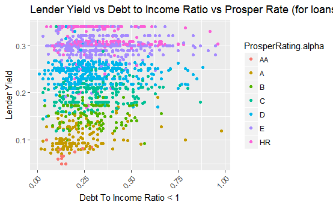

```r
ggplot(aes(x= DebtToIncomeRatio, y=LenderYield, color=ProsperRating.alpha),
    data=na.omit(filter(pf, DebtToIncomeRatio < 1))) +
    geom_point(alpha = 1) +
    #scale_y_log10() +
    #facet_grid(.~ ProsperRating.alpha ) +
    theme(axis.text.x = element_text(angle = 45, hjust = 1))+
    ggtitle("Lender Yield vs Debt to Income Ratio vs Prosper Rate (for loans with rating") +
    xlab ("Debt To Income Ratio < 1") +
    ylab ("Lender Yield") +
    scale_fill_discrete(name = "Prosper Rating")
```

This chart shows the coorelation of the Lender Yield, the Prosper Rating and the Debt-To-Income Ratio.

### C2. LENDER YIELD vs PROSPER RATE vs TERM

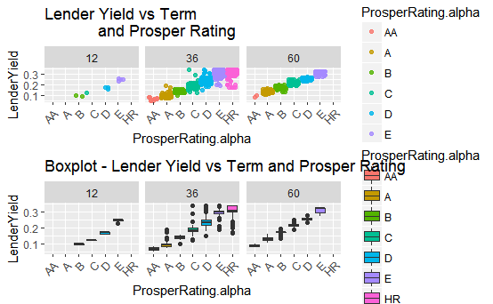

```r
plot1 <- ggplot(aes(x= ProsperRating.alpha, y=LenderYield,
                                  color=ProsperRating.alpha),
       data=na.omit(filter(pf, DebtToIncomeRatio < 1))) +
    geom_point(alpha = 0.8, position = "jitter") +
    facet_grid( .~ Term  ) +
    theme(axis.text.x = element_text(angle = 45, hjust = 1))+
    ggtitle("Lender Yield vs Term
            and Prosper Rating")
plot2 <- ggplot(aes(x= ProsperRating.alpha, y= LenderYield ),
       data=na.omit(filter(pf, DebtToIncomeRatio < 1))) +
    geom_boxplot(aes(fill = ProsperRating.alpha)) +
    facet_grid( .~ Term   ) +
    theme(axis.text.x = element_text(angle = 45, hjust = 1))+
    ggtitle("Boxplot - Lender Yield vs Term and Prosper Rating")
grid.arrange(plot1, plot2, ncol=1, nrow =2)
```

# D. FINAL PLOTS & SUMMARY

### PROSPER RATING

```
Ignoring unknown parameters: binwidth, bins, pad
```

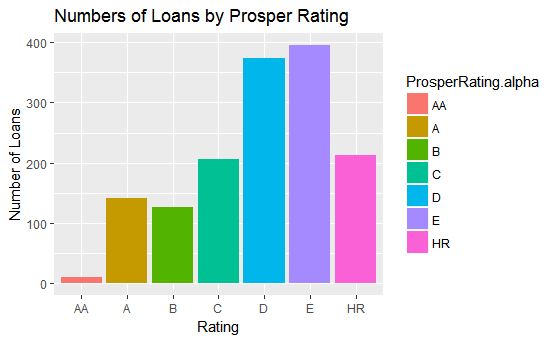

```r
ggplot(data = na.omit(pf), aes(ProsperRating.alpha)) +
  geom_histogram(aes(fill = ProsperRating.alpha),stat="count") +
  ggtitle('Numbers of Loans by Prosper Rating') +
  xlab('Rating') +
  ylab('Number of Loans')
```

```r
summary(pf$ProsperRating.alpha)
```

```
   AA     A     B     C     D     E    HR    NA  NA's
 5372 14551 15581 18345 14274  9795  6935     0 29084
```

### DEBT TO INCOME RATIO

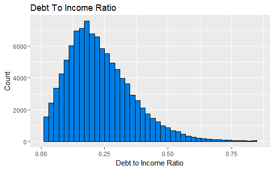

```r
ggplot(data = pf, aes(x = DebtToIncomeRatio)) +
        geom_histogram(color = "black", fill = '#007EE5', binwidth = 0.02) +
        xlim(0, quantile(pf$DebtToIncomeRatio, prob = 0.99, na.rm=TRUE)) +
        ggtitle("Debt To Income Ratio") +
        xlab("Debt to Income Ratio") +
        ylab("Count")
```

Similar to the graph above, I chose the Debt to Income Ratio graph as a final chart because it is important to see that the debt-to-income ratio for most borrowers is less than 0.25.

### DEBT TO INCOME RATIO, LENDER YIELD AND PROSPER RATING

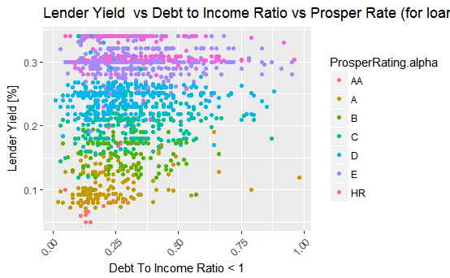

```r
ggplot(aes(x= DebtToIncomeRatio, y=LenderYield, color=ProsperRating.alpha),
       data=na.omit(filter(pf, DebtToIncomeRatio < 1))) +
  geom_point(alpha = 1) +
  #scale_y_log10() +
  #facet_grid(.~ ProsperRating.alpha ) +
  theme(axis.text.x = element_text(angle = 45, hjust = 1))+
  ggtitle("Lender Yield  vs Debt to Income Ratio vs Prosper Rate (for loans with rating)") +
  xlab ("Debt To Income Ratio < 1") +
  ylab ("Lender Yield [%]") +
  scale_fill_discrete(name = "Prosper Rating")
```

I chose to show this chart as one of the final three plots because I believe this shows the relationships between the Lender Yield and Prosper Rating. This shows that the higher the risk, the lower the rating and the better lender yield. A high Prosper Rating rating woul have a good debt-to-income ratio, which creates the upward triangle shape.

# E. REFLECTION